# TimeSeriesModels_DSCI8950

Read Combined Dataset that we built for Zillow based on Exploratory Analysis result with Values for each Year on Combination of State and County Name for each of AllHomes, 3 Bed Room, 2 Bed Room, Condo , Percapita Income, Population Growth

This dataset is input from Exploratory Analysis Result.

In this process we build Statistical Time Series Models using ARIMA, SARIMA and PROPHET.

```python
import xgboost as xgb
import pandas as pd
import os
import numpy as np
from sklearn.model_selection import train_test_split
from sklearn.metrics import mean_squared_error, r2_score
from sklearn.preprocessing import StandardScaler
pd.set_option('display.max_columns', None)
dirpath = os.path.join(os.getcwd(), "DS_2025_TeamE\data_files")
# Check if directory exists
if not os.path.exists(dirpath):
    raise FileNotFoundError(f"The directory {dirpath} does not exist.")
else:
    print(f"The directory {dirpath} exists.")
    # List all files in the directory
files_in_dir = os.listdir(dirpath)
print(dirpath)
zhvi_filename = 'zillow_combined_zhvi.csv'
zhvi_filepath = os.path.join(dirpath, zhvi_filename)
zhvi_condo_df = pd.read_csv(zhvi_filepath, header=None)  # Read without headers
zhvi_condo_df.columns = zhvi_condo_df.iloc[0]  # Set first row as column names
zhvi_condo_df = zhvi_condo_df[1:].reset_index(drop=True)  # Remove first row from data
zhvi_condo_fmt_df = zhvi_condo_df.copy()
```

```
The directory c:\Users\req92163\OneDrive - Mutual of Omaha\DSCI8950\DS_2025_TeamE\data_files exists.
c:\Users\req92163\OneDrive - Mutual of Omaha\DSCI8950\DS_2025_TeamE\data_files
```

Convert Deicmal Values to Integers . Replace Nulls with Zeroes.

```python
# Ensure 'Personal_Income_Growth' is of numeric type before imputation
zhvi_condo_fmt_df['Personal_Income_Growth'] = pd.to_numeric(zhvi_condo_fmt_df['Personal_Income_Growth'], errors='coerce')
zhvi_condo_fmt_df['Population_Growth'] = pd.to_numeric(zhvi_condo_fmt_df['Population_Growth'], errors='coerce')
zhvi_condo_fmt_df['Per_Capita_Income_Growth'] = pd.to_numeric(zhvi_condo_fmt_df['Per_Capita_Income_Growth'], errors='coerce')
numeric_cols = zhvi_condo_fmt_df.select_dtypes(include=[np.number]).columns
zhvi_condo_fmt_df[numeric_cols] = zhvi_condo_fmt_df[numeric_cols].fillna(0)
zhvi_condo_fmt_df['Previous_AnnualValue_AllHomes'] = zhvi_condo_fmt_df['Previous_AnnualValue_AllHomes'].replace(0, np.nan)
zhvi_condo_fmt_df = zhvi_condo_fmt_df[['County', 'State', 'Year_Recorded',
                                       'Personal_Income_Growth', 'Population_Growth', 'Per_Capita_Income_Growth',
                                       'AnnualValue_AllHomes', 'Previous_AnnualValue_AllHomes', 'Annual_Increase_AllHomes',
                                       'AnnualValue_SingleFamily', 'Previous_AnnualValue_SingleFamily','Annual_Increase_SingleFamily',
                                       'AnnualValue_Condo', 'Previous_AnnualValue_Condo', 'Annual_Increase_Condo',
                                       'AnnualValue_ThreeBedRoom', 'Previous_AnnualValue_ThreeBedRoom', 'Annual_Increase_ThreeBedRoom',
                                       'AnnualValue_TwoBedRoom', 'Previous_AnnualValue_TwoBedRoom', 'Annual_Increase_TwoBedRoom']]
# Convert all object columns to numeric except 'County' and 'State'
columns_to_convert = zhvi_condo_fmt_df.select_dtypes(include=['object']).columns.difference(['County', 'State'])
zhvi_condo_fmt_df[columns_to_convert] = zhvi_condo_fmt_df[columns_to_convert].apply(pd.to_numeric, errors='coerce')
zhvi_condo_fmt_df[numeric_cols] = zhvi_condo_fmt_df[numeric_cols].fillna(0)
zhvi_condo_fmt_df[zhvi_condo_fmt_df.select_dtypes(include=['float64']).columns] = zhvi_condo_fmt_df.select_dtypes(include=['float64']).fillna(0)
# Convert specific columns to nearest integer
zhvi_condo_fmt_df['Personal_Income_Growth'] = zhvi_condo_fmt_df['Personal_Income_Growth'].round(0).astype(int)
zhvi_condo_fmt_df['Population_Growth'] = zhvi_condo_fmt_df['Population_Growth'].round(0).astype(int)
zhvi_condo_fmt_df['Per_Capita_Income_Growth'] = zhvi_condo_fmt_df['Per_Capita_Income_Growth'].round(0).astype(int)
zhvi_condo_fmt_df['Annual_Increase_AllHomes'] = zhvi_condo_fmt_df['Annual_Increase_AllHomes'].round(0).astype(int)

# Convert all remaining float columns to nearest 100
float_cols = zhvi_condo_fmt_df.select_dtypes(include=['float64']).columns.difference(['Personal_Income_Growth', 'Population_Growth', 'Per_Capita_Income_Growth', 'Annual_Increase_AllHomes'])
zhvi_condo_fmt_df[float_cols] = zhvi_condo_fmt_df[float_cols].apply(lambda x: (x / 100).round(0) * 100)
float_cols = zhvi_condo_fmt_df.select_dtypes(include=['float64']).columns
zhvi_condo_fmt_df[float_cols] = zhvi_condo_fmt_df[float_cols].astype(int)
zhvi_condo_fmt_df.isnull().sum()
merged_df = zhvi_condo_fmt_df[['County', 'State', 'Year_Recorded', 'AnnualValue_AllHomes']].copy()
merged_df['Type'] = 'Actual'
```

```python
from statsmodels.graphics.tsaplots import plot_acf, plot_pacf
import matplotlib.pyplot as plt

def autocorrelation_plots(data, description="", n_lags=20):
    """
    Plot ACF and PACF for the given data.

    Parameters:
    - data: The data for which to plot ACF and PACF.
    - description: A string to describe the data (used in plot titles).
    - n_lags: Number of lags to include in the plots.
    """
    plt.figure(figsize=(12, 6))

    # Plot ACF
    plt.subplot(1, 2, 1)
    plot_acf(data, lags=n_lags, ax=plt.gca())
    plt.title(f"ACF of {description}")

    # Plot PACF
    plt.subplot(1, 2, 2)
    plot_pacf(data, lags=n_lags, ax=plt.gca())
    plt.title(f"PACF of {description}")

    plt.tight_layout()
    plt.show()
```

```python
def evaluate_regression_model(model, X_test, y_test, category):
    y_pred_test = model.predict(X_test)

    test_rmse = round(np.sqrt(mean_squared_error(y_test, y_pred_test)), -2)
    test_mae = round(mean_absolute_error(y_test, y_pred_test), -2)

    results_df = pd.DataFrame({
        'Category': [category],
        'Test RMSE': [int(test_rmse)],
        'Test MAE': [int(test_mae)]
    })

    return results_df
```

```python
from statsmodels.tsa.arima.model import ARIMA
from sklearn.metrics import mean_squared_error, r2_score, mean_absolute_error
import warnings

# Suppress all warnings
warnings.filterwarnings("ignore")

# Suppress all errors (optional, but not recommended for debugging)
import sys
sys.tracebacklimit = 0
def train_and_evaluate_arima_for_all(df, target_column):
    """
    Train an ARIMA model and evaluate its performance on test data (2024) for each State and County.
    Calculate the overall RMSE and MAE for the entire test set (2024).
    """
    # List to store results for all States and Counties
    results = []
    all_actuals = []  # To store all actual values
    all_predictions = []  # To store all predicted values

    # Iterate through each unique combination of State and County
    for state in df['State'].unique():
        for county in df['County'].unique():

            # Filter data for the specific State and County
            arima_df = df[(df['State'] == state) & (df['County'] == county)]

            if arima_df.empty:
                continue

            # Prepare data for ARIMA
            arima_df = arima_df[['Year_Recorded', target_column]].rename(columns={'Year_Recorded': 'ds', target_column: 'y'})
            arima_df['ds'] = pd.to_datetime(arima_df['ds'], format='%Y')
            arima_df.set_index('ds', inplace=True)

            # Split data into train (2019-2023) and test (2024)
            train_data = arima_df[arima_df.index.year < 2024]
            test_data = arima_df[arima_df.index.year == 2024]

            # If there is no test data (e.g., 2024), skip this iteration
            if test_data.empty:
                continue

            # Fit ARIMA model
            model = ARIMA(train_data['y'], order=(1, 1, 1))  # Adjust order as needed
            model_fit = model.fit()

            # Forecast for 2024
            forecast = model_fit.forecast(steps=1)
            predicted_2024 = forecast[0]
            actual_2024 = test_data['y'].iloc[0]

            # Convert actuals and predictions to integers rounded to the nearest 100
            predicted_2024 = int(round(predicted_2024 / 100) * 100)
            actual_2024 = int(round(actual_2024 / 100) * 100)

            # Calculate evaluation metrics for this State-County pair
            mae = int(round(mean_absolute_error([actual_2024], [predicted_2024]), -1))
            rmse = int(round(np.sqrt(mean_squared_error([actual_2024], [predicted_2024])), -1))
            r2 = r2_score([actual_2024], [predicted_2024])

            # Append results for this State-County pair
            results.append({
                'State': state,
                'County': county,
                'Year': 2024,
                'Predicted_2024': predicted_2024,
                'Actual_2024': actual_2024,
                'MAE': mae,
                'RMSE': rmse
            })

            # Append to the lists of actual and predicted values
            all_actuals.append(actual_2024)
            all_predictions.append(predicted_2024)

    # Calculate overall RMSE and MAE for the entire test set (across all State-County pairs)
    overall_rmse = int(round(np.sqrt(mean_squared_error(all_actuals, all_predictions)), -1))
    overall_mae = int(round(mean_absolute_error(all_actuals, all_predictions), -1))

    # Print the overall RMSE and MAE for the test set along with the target column
    print(f"Target Column: {target_column}")
    print(f"Overall RMSE for the test set (2024): {overall_rmse}")
    print(f"Overall MAE for the test set (2024): {overall_mae}")

    # Return the detailed results, overall RMSE, and overall MAE
    return pd.DataFrame(results), overall_rmse, overall_mae

# Example usage for 'AnnualValue_AllHomes'
arima_predict_results_allhomes_df, arima_rmse_allhomes, arima_mae_allhomes = train_and_evaluate_arima_for_all(zhvi_condo_fmt_df, 'AnnualValue_AllHomes')
# Predict for 'SingleFamily'
arima_predict_results_singlefamily_df, arima_rmse_singlefamily, arima_mae_singlefamily = train_and_evaluate_arima_for_all(zhvi_condo_fmt_df, 'AnnualValue_SingleFamily')

# Predict for 'Condo'
arima_predict_results_condo_df, arima_rmse_condo, arima_mae_condo = train_and_evaluate_arima_for_all(zhvi_condo_fmt_df, 'AnnualValue_Condo')

# Predict for 'TwoBedRoom'
arima_predict_results_twobedroom_df, arima_rmse_twobedroom, arima_mae_twobedroom = train_and_evaluate_arima_for_all(zhvi_condo_fmt_df, 'AnnualValue_TwoBedRoom')

# Predict for 'ThreeBedRoom'
arima_predict_results_threebedroom_df, arima_rmse_threebedroom, arima_mae_threebedroom = train_and_evaluate_arima_for_all(zhvi_condo_fmt_df, 'AnnualValue_ThreeBedRoom')
```

```
Target Column: AnnualValue_AllHomes
Overall RMSE for the test set (2024): 13370
Overall MAE for the test set (2024): 7060
Target Column: AnnualValue_SingleFamily
Overall RMSE for the test set (2024): 20300
Overall MAE for the test set (2024): 7340
Target Column: AnnualValue_Condo
Overall RMSE for the test set (2024): 7440
Overall MAE for the test set (2024): 2770
Target Column: AnnualValue_TwoBedRoom
Overall RMSE for the test set (2024): 7550
Overall MAE for the test set (2024): 4060
Target Column: AnnualValue_ThreeBedRoom
Overall RMSE for the test set (2024): 12290
Overall MAE for the test set (2024): 5900
```

```python
# Evaluate the ARIMA model for 'AnnualValue_AllHomes'
results_allhomes = pd.DataFrame({
    'Category': ['AllHomes'],
    'Test RMSE': [arima_rmse_allhomes],
    'Test MAE': [arima_mae_allhomes]
})

# Evaluate the ARIMA model for 'AnnualValue_Condo'
results_condo = pd.DataFrame({
    'Category': ['Condo'],
    'Test RMSE': [arima_rmse_condo],
    'Test MAE': [arima_mae_condo]
})

# Evaluate the ARIMA model for 'AnnualValue_SingleFamily'
results_singlefamily = pd.DataFrame({
    'Category': ['SingleFamily'],
    'Test RMSE': [arima_rmse_singlefamily],
    'Test MAE': [arima_mae_singlefamily]
})

# Evaluate the ARIMA model for 'AnnualValue_ThreeBedRoom'
results_threebedroom = pd.DataFrame({
    'Category': ['ThreeBedRoom'],
    'Test RMSE': [arima_rmse_threebedroom],
    'Test MAE': [arima_mae_threebedroom]
})

# Evaluate the ARIMA model for 'AnnualValue_TwoBedRoom'
results_twobedroom = pd.DataFrame({
    'Category': ['TwoBedRoom'],
    'Test RMSE': [arima_rmse_twobedroom],
    'Test MAE': [arima_mae_twobedroom]
})

# Merge all results into one dataframe
arima_results_df = pd.concat([results_allhomes, results_condo, results_singlefamily, results_threebedroom, results_twobedroom], ignore_index=True)
arima_results_df
```

|  | Category | Test RMSE | Test MAE |
| --- | --- | --- | --- |
| 0 | AllHomes | 13370 | 7060 |
| 1 | Condo | 7440 | 2770 |
| 2 | SingleFamily | 20300 | 7340 |
| 3 | ThreeBedRoom | 12290 | 5900 |
| 4 | TwoBedRoom | 7550 | 4060 |

Plot the actual vs predicted values

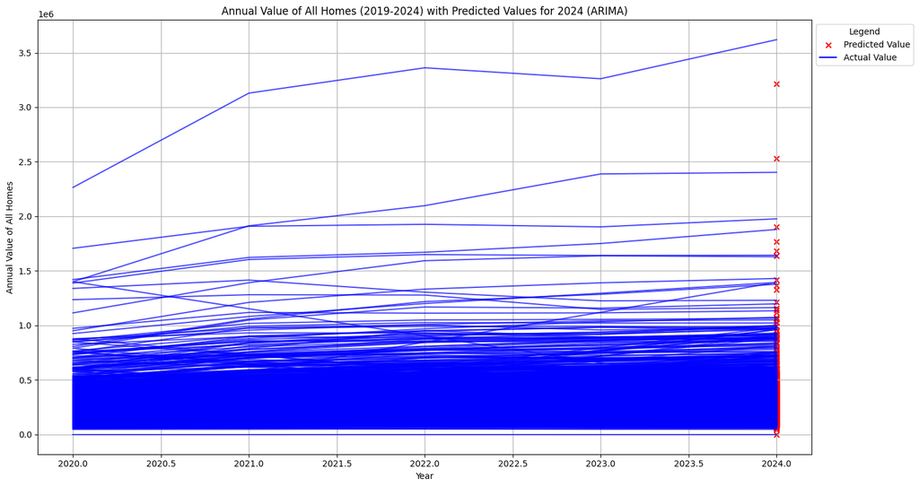

```python
import matplotlib.pyplot as plt
arima_predict_results_allhomes_df['Type'] = 'Predicted'

# Rename columns to match the actual data for concatenation
arima_predict_results_allhomes_df.rename(columns={'Predicted_2024': 'AnnualValue_AllHomes', 'Year': 'Year_Recorded'}, inplace=True)

# Filter the predicted data to include only the year 2024
arima_predict_results_allhomes_df = arima_predict_results_allhomes_df[arima_predict_results_allhomes_df['Year_Recorded'] == 2024]

# Concatenate the actual and predicted data
plot_arima_df = pd.concat([merged_df, arima_predict_results_allhomes_df[['County', 'State', 'Year_Recorded', 'AnnualValue_AllHomes', 'Type']]])

# Plot the data
plt.figure(figsize=(15, 8))

# Plot actual values
actual_data = plot_arima_df[plot_arima_df['Type'] == 'Actual']
for county in actual_data['County'].unique():
    county_data = actual_data[actual_data['County'] == county]
    plt.plot(county_data['Year_Recorded'], county_data['AnnualValue_AllHomes'], color='blue', alpha=0.7)

# Highlight predicted values with a different marker
predicted_data = plot_arima_df[plot_arima_df['Type'] == 'Predicted']
plt.scatter(predicted_data['Year_Recorded'], predicted_data['AnnualValue_AllHomes'], color='red', label='Predicted Value', marker='x')

# Add labels and legend
plt.title('Annual Value of All Homes (2019-2024) with Predicted Values for 2024 (ARIMA)')
plt.xlabel('Year')
plt.ylabel('Annual Value of All Homes')
plt.plot([], [], color='blue', label='Actual Value')  # Add a dummy plot for the legend
plt.legend(loc='upper left', bbox_to_anchor=(1, 1), title='Legend')
plt.grid(True)
plt.tight_layout()
plt.show()
```

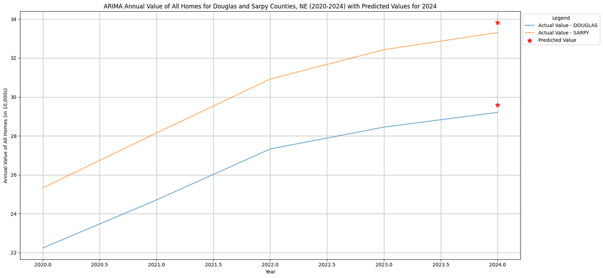

```python
import matplotlib.pyplot as plt
from matplotlib.ticker import FuncFormatter, MultipleLocator

# Merge actual values from zhvi_condo_fmt_df and predicted values from arima_predict_results_df

# Add predicted values to the merged dataframe
arima_predict_results_allhomes_df['Type'] = 'Predicted'
arima_predict_results_allhomes_df.rename(columns={'Predicted_2024': 'AnnualValue_AllHomes'}, inplace=True)
arima_predict_results_allhomes_df['Year_Recorded'] = 2024  # Ensure the year is set to 2024

# Concatenate the actual and predicted data
plot_df = pd.concat([merged_df, arima_predict_results_allhomes_df[['County', 'State', 'Year_Recorded', 'AnnualValue_AllHomes', 'Type']]])

# Filter for specific County and State (Douglas, NE)
plot_df = plot_df[(plot_df['County'].isin(['DOUGLAS', 'SARPY'])) & (plot_df['State'] == 'NE')]

# Remove duplicates if they exist
plot_df = plot_df.drop_duplicates(subset=['County', 'State', 'Year_Recorded', 'Type'])

# Sort data based on State, County, and Year_Recorded
plot_df = plot_df.sort_values(by=['State', 'County', 'Year_Recorded', 'Type'])

# Plot the data
plt.figure(figsize=(15, 8))

# Plot actual values for 'DOUGLAS' and 'SARPY' counties in 'NE'
actual_data = plot_df[plot_df['Type'] == 'Actual']
for county in actual_data['County'].unique():
    county_data = actual_data[actual_data['County'] == county]
    plt.plot(county_data['Year_Recorded'], county_data['AnnualValue_AllHomes'], label=f'Actual Value - {county}', alpha=0.7)

# Highlight predicted values with a different marker
predicted_data = plot_df[plot_df['Type'] == 'Predicted']
if not predicted_data.empty:
    plt.scatter(predicted_data['Year_Recorded'], predicted_data['AnnualValue_AllHomes'], color='red', label='Predicted Value', marker='*', s=100)

# Add labels and legend
plt.title('ARIMA Annual Value of All Homes for Douglas and Sarpy Counties, NE (2020-2024) with Predicted Values for 2024')
plt.xlabel('Year')
plt.ylabel('Annual Value of All Homes (in 10,000s)')

# Add custom y-axis formatter
formatter_y = FuncFormatter(lambda x, _: f'{int(x / 10000)}')  # Custom format to show units of 10,000 for y-axis
plt.gca().yaxis.set_major_formatter(formatter_y)


# Set grid and adjust the layout
plt.grid(True)

# Add annotation on y-axis to explain the formatting (22 means 22 * 10,000)
##plt.text(2020, 22, '22 means 22 * 10,000', fontsize=12, color='black', ha='center', va='center',
 ##        rotation=90, bbox=dict(facecolor='white', edgecolor='black', boxstyle='round,pad=0.5'))

# Add annotations to explain y-axis formatting
##plt.text(2020, 220, 'Values are in units of 10,000\n(i.e., 22 means 22 * 10,000)',
##         fontsize=12, color='black', ha='center', va='center', bbox=dict(facecolor='white', edgecolor='black', boxstyle='round,pad=0.5'))

# Adjust layout for better display
plt.tight_layout()

# Add the legend
plt.legend(loc='upper left', bbox_to_anchor=(1, 1), title='Legend')

# Show the plot
plt.show()
```

```python
arima_predict_results_allhomes_df
```

|  | State | County | Year_Recorded | AnnualValue_AllHomes | Actual_2024 | MAE | RMSE | Type |
| --- | --- | --- | --- | --- | --- | --- | --- | --- |
| 0 | AL | AUTAUGA | 2024 | 196200 | 202500 | 6300 | 6300 | Predicted |
| 1 | AL | BALDWIN | 2024 | 351800 | 349500 | 2300 | 2300 | Predicted |
| 2 | AL | BARBOUR | 2024 | 142200 | 145800 | 3600 | 3600 | Predicted |
| 3 | AL | BIBB | 2024 | 193700 | 198500 | 4800 | 4800 | Predicted |
| 4 | AL | BLOUNT | 2024 | 224000 | 229300 | 5300 | 5300 | Predicted |
| ... | ... | ... | ... | ... | ... | ... | ... | ... |
| 2194 | WY | NATRONA | 2024 | 256000 | 259500 | 3500 | 3500 | Predicted |
| 2195 | WY | SHERIDAN | 2024 | 467800 | 486300 | 18500 | 18500 | Predicted |
| 2196 | WY | SWEETWATER | 2024 | 228800 | 232500 | 3700 | 3700 | Predicted |
| 2197 | WY | UINTA | 2024 | 344200 | 353200 | 9000 | 9000 | Predicted |
| 2198 | WY | WESTON | 2024 | 235700 | 242400 | 6700 | 6700 | Predicted |

2199 rows × 8 columns

Build SARIMA model to predict House Values. Include additional Features as 'Personal_Income_Growth', 'Population_Growth', 'Per_Capita_Income_Growth'

```python
from statsmodels.tsa.statespace.sarimax import SARIMAX

def train_and_evaluate_sarima_with_exog_for_all(df, target_column, exog_columns):
    """
    Train a SARIMA model with exogenous variables and evaluate its performance on test data (2024) for each State and County.
    Calculate the overall RMSE and MAE for the entire test set (2024).
    """
    results = []
    all_actuals = []
    all_predictions = []

    for state in df['State'].unique():
        for county in df['County'].unique():
            sarima_df = df[(df['State'] == state) & (df['County'] == county)]
            if sarima_df.empty:
                continue

            sarima_df = sarima_df[['Year_Recorded', target_column] + exog_columns].rename(columns={'Year_Recorded': 'ds', target_column: 'y'})
            sarima_df['ds'] = pd.to_datetime(sarima_df['ds'], format='%Y')
            sarima_df.set_index('ds', inplace=True)

            train_data = sarima_df[sarima_df.index.year < 2024]
            test_data = sarima_df[sarima_df.index.year == 2024]

            if test_data.empty:
                continue

            train_y = train_data['y']
            train_exog = train_data[exog_columns]
            test_y = test_data['y']
            test_exog = test_data[exog_columns]

            model = SARIMAX(train_y, exog=train_exog, order=(1, 1, 1), seasonal_order=(1, 1, 1, 12))
            model_fit = model.fit(disp=False)

            forecast = model_fit.forecast(steps=len(test_y), exog=test_exog)
            for i, (predicted, actual) in enumerate(zip(forecast, test_y)):
                year = test_y.index[i].year
                mae = mean_absolute_error([actual], [predicted])
                rmse = np.sqrt(mean_squared_error([actual], [predicted]))

                results.append({
                    'State': state,
                    'County': county,
                    'Year': year,
                    'Predicted': predicted,
                    'Actual': actual,
                    'MAE': mae,
                    'RMSE': rmse
                })

                all_actuals.append(actual)
                all_predictions.append(predicted)

    overall_rmse = np.sqrt(mean_squared_error(all_actuals, all_predictions))
    overall_mae = mean_absolute_error(all_actuals, all_predictions)
    print(f"Overall RMSE for the test set (2024): {overall_rmse:.2f}")
    print(f"Overall MAE for the test set (2024): {overall_mae:.2f}")

    return pd.DataFrame(results), overall_rmse, overall_mae

# Example usage for 'AnnualValue_AllHomes' with additional features
exog_features = ['Personal_Income_Growth', 'Population_Growth', 'Per_Capita_Income_Growth']

# Predict for 'AnnualValue_AllHomes'
sarima_predict_results_allhomes_df, sarima_rmse_allhomes, sarima_mae_allhomes = train_and_evaluate_sarima_with_exog_for_all(zhvi_condo_fmt_df, 'AnnualValue_AllHomes', exog_features)

# Predict for 'SingleFamily'
sarima_predict_results_singlefamily_df, sarima_rmse_singlefamily, sarima_mae_singlefamily = train_and_evaluate_sarima_with_exog_for_all(zhvi_condo_fmt_df, 'AnnualValue_SingleFamily', exog_features)

# Predict for 'Condo'
sarima_predict_results_condo_df, sarima_rmse_condo, sarima_mae_condo = train_and_evaluate_sarima_with_exog_for_all(zhvi_condo_fmt_df, 'AnnualValue_Condo', exog_features)

# Predict for 'TwoBedRoom'
sarima_predict_results_twobedroom_df, sarima_rmse_twobedroom, sarima_mae_twobedroom = train_and_evaluate_sarima_with_exog_for_all(zhvi_condo_fmt_df, 'AnnualValue_TwoBedRoom', exog_features)

# Predict for 'ThreeBedRoom'
sarima_predict_results_threebedroom_df, sarima_rmse_threebedroom, sarima_mae_threebedroom = train_and_evaluate_sarima_with_exog_for_all(zhvi_condo_fmt_df, 'AnnualValue_ThreeBedRoom', exog_features)
```

```
Overall RMSE for the test set (2024): 16329.37
Overall MAE for the test set (2024): 11350.11
Overall RMSE for the test set (2024): 22607.14
Overall MAE for the test set (2024): 11672.67
Overall RMSE for the test set (2024): 8014.08
Overall MAE for the test set (2024): 3212.19
Overall RMSE for the test set (2024): 10247.13
Overall MAE for the test set (2024): 6703.91
Overall RMSE for the test set (2024): 16149.17
Overall MAE for the test set (2024): 11018.64
```

Build Test RMSE and MAE for all House Categories.

```python
# Evaluate the SARIMA model for 'AnnualValue_AllHomes'
results_allhomes = pd.DataFrame({
    'Category': ['AllHomes'],
    'Test RMSE': [int(round(sarima_rmse_allhomes))],
    'Test MAE': [int(round(sarima_mae_allhomes))]
})

# Evaluate the SARIMA model for 'AnnualValue_Condo'
results_condo = pd.DataFrame({
    'Category': ['Condo'],
    'Test RMSE': [int(round(sarima_rmse_condo))],
    'Test MAE': [int(round(sarima_mae_condo))]
})

# Evaluate the SARIMA model for 'AnnualValue_SingleFamily'
results_singlefamily = pd.DataFrame({
    'Category': ['SingleFamily'],
    'Test RMSE': [int(round(sarima_rmse_singlefamily))],
    'Test MAE': [int(round(sarima_mae_singlefamily))]
})

# Evaluate the SARIMA model for 'AnnualValue_ThreeBedRoom'
results_threebedroom = pd.DataFrame({
    'Category': ['ThreeBedRoom'],
    'Test RMSE': [int(round(sarima_rmse_threebedroom))],
    'Test MAE': [int(round(sarima_mae_threebedroom))]
})

# Evaluate the SARIMA model for 'AnnualValue_TwoBedRoom'
results_twobedroom = pd.DataFrame({
    'Category': ['TwoBedRoom'],
    'Test RMSE': [int(round(sarima_rmse_twobedroom))],
    'Test MAE': [int(round(sarima_mae_twobedroom))]
})

# Merge all results into one dataframe
sarima_results_df = pd.concat([results_allhomes, results_condo, results_singlefamily, results_threebedroom, results_twobedroom], ignore_index=True)
sarima_results_df
```

|  | Category | Test RMSE | Test MAE |
| --- | --- | --- | --- |
| 0 | AllHomes | 16329 | 11350 |
| 1 | Condo | 8014 | 3212 |
| 2 | SingleFamily | 22607 | 11673 |
| 3 | ThreeBedRoom | 16149 | 11019 |
| 4 | TwoBedRoom | 10247 | 6704 |

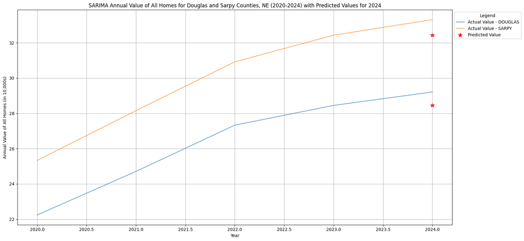

```python
import matplotlib.pyplot as plt
from matplotlib.ticker import FuncFormatter, MultipleLocator

# Merge actual values from zhvi_condo_fmt_df and predicted values from sarima_predict_results_allhomes_df

# Add predicted values to the merged dataframe
sarima_predict_results_allhomes_df['Type'] = 'Predicted'
sarima_predict_results_allhomes_df.rename(columns={'Predicted': 'AnnualValue_AllHomes', 'Year': 'Year_Recorded'}, inplace=True)
sarima_predict_results_allhomes_df['Year_Recorded'] = 2024  # Ensure the year is set to 2024

# Concatenate the actual and predicted data
plot_df = pd.concat([merged_df, sarima_predict_results_allhomes_df[['County', 'State', 'Year_Recorded', 'AnnualValue_AllHomes', 'Type']]])

# Filter for specific County and State (Douglas, NE)
plot_df = plot_df[(plot_df['County'].isin(['DOUGLAS', 'SARPY'])) & (plot_df['State'] == 'NE')]

# Remove duplicates if they exist
plot_df = plot_df.drop_duplicates(subset=['County', 'State', 'Year_Recorded', 'Type'])

# Sort data based on State, County, and Year_Recorded
plot_df = plot_df.sort_values(by=['State', 'County', 'Year_Recorded', 'Type'])

# Plot the data
plt.figure(figsize=(15, 8))

# Plot actual values for 'DOUGLAS' and 'SARPY' counties in 'NE'
actual_data = plot_df[plot_df['Type'] == 'Actual']
for county in actual_data['County'].unique():
    county_data = actual_data[actual_data['County'] == county]
    plt.plot(county_data['Year_Recorded'], county_data['AnnualValue_AllHomes'], label=f'Actual Value - {county}', alpha=0.7)

# Highlight predicted values with a different marker
predicted_data = plot_df[plot_df['Type'] == 'Predicted']
if not predicted_data.empty:
    plt.scatter(predicted_data['Year_Recorded'], predicted_data['AnnualValue_AllHomes'], color='red', label='Predicted Value', marker='*', s=100)

# Add labels and legend
plt.title('SARIMA Annual Value of All Homes for Douglas and Sarpy Counties, NE (2020-2024) with Predicted Values for 2024')
plt.xlabel('Year')
plt.ylabel('Annual Value of All Homes (in 10,000s)')

# Add custom y-axis formatter
formatter_y = FuncFormatter(lambda x, _: f'{int(x / 10000)}')  # Custom format to show units of 10,000 for y-axis
plt.gca().yaxis.set_major_formatter(formatter_y)

# Set grid and adjust the layout
plt.grid(True)

# Adjust layout for better display
plt.tight_layout()

# Add the legend
plt.legend(loc='upper left', bbox_to_anchor=(1, 1), title='Legend')

# Show the plot
plt.show()
```

```python
sarima_predict_results_allhomes_df = sarima_predict_results_allhomes_df.astype({col: 'int' for col in sarima_predict_results_allhomes_df.select_dtypes(include=['float64', 'int64']).columns})
sarima_predict_results_allhomes_df.head(10)
```

|  | State | County | Year_Recorded | AnnualValue_AllHomes | Actual | MAE | RMSE | Type |
| --- | --- | --- | --- | --- | --- | --- | --- | --- |
| 0 | AL | AUTAUGA | 2024 | 194400 | 202500 | 8100 | 8100 | Predicted |
| 1 | AL | BALDWIN | 2024 | 345400 | 349500 | 4100 | 4100 | Predicted |
| 2 | AL | BARBOUR | 2024 | 142300 | 145800 | 3500 | 3500 | Predicted |
| 3 | AL | BIBB | 2024 | 192900 | 198500 | 5600 | 5600 | Predicted |
| 4 | AL | BLOUNT | 2024 | 222700 | 229300 | 6600 | 6600 | Predicted |
| 5 | AL | BULLOCK | 2024 | 94100 | 98200 | 4100 | 4100 | Predicted |
| 6 | AL | CALHOUN | 2024 | 167700 | 172200 | 4500 | 4500 | Predicted |
| 7 | AL | CHAMBERS | 2024 | 158700 | 167500 | 8800 | 8800 | Predicted |
| 8 | AL | CHILTON | 2024 | 212600 | 219500 | 6900 | 6900 | Predicted |
| 9 | AL | CLAY | 2024 | 136100 | 136700 | 600 | 600 | Predicted |

Build Prophet Model for Timeseries build.

```python
from prophet import Prophet
import warnings
import logging

# Suppress warnings and logging messages that contain "cmdstanpy"
warnings.filterwarnings("ignore", message=".*cmdstanpy.*")
logging.getLogger("cmdstanpy").setLevel(logging.CRITICAL)
import warnings

# Suppress all warnings
warnings.filterwarnings("ignore")

# Suppress all errors (optional, but not recommended for debugging)
import sys
sys.tracebacklimit = 0
# Modify the function to exclude exogenous features
def train_and_evaluate_prophet_for_all(df, target_column):
    """
    Train a Prophet model and evaluate its performance on test data (2024) for each State and County.
    Calculate the overall RMSE and MAE for the entire test set (2024).
    """
    # Preprocess the data once to avoid redundant operations
    df = df[['State', 'County', 'Year_Recorded', target_column]].rename(
        columns={'Year_Recorded': 'ds', target_column: 'y'}
    )
    df['ds'] = pd.to_datetime(df['ds'], format='%Y')

    # Split data into train (before 2024) and test (2024)
    train_data = df[df['ds'].dt.year < 2024]
    test_data = df[df['ds'].dt.year == 2024]

    # If no test data exists, return early
    if test_data.empty:
        print(f"No test data available for 2024 for {target_column}.")
        return pd.DataFrame(), None, None

    # Group data by State and County for parallel processing
    grouped_train = train_data.groupby(['State', 'County'])
    grouped_test = test_data.groupby(['State', 'County'])

    results = []
    all_actuals = []
    all_predictions = []

    for (state, county), train_group in grouped_train:
        # Check if test data exists for this State-County pair
        if (state, county) not in grouped_test.groups:
            continue

        test_group = grouped_test.get_group((state, county))

        # Fit Prophet model
        model = Prophet(holidays=None, yearly_seasonality=False, weekly_seasonality=False)

        # Fit Prophet model without exogenous features
        model.fit(train_group)

        # Create a future dataframe with the specific date for 2024
        future = pd.DataFrame({'ds': pd.to_datetime(['2024-01-01'])})

        # Forecast for the future period
        forecast = model.predict(future)

        # Extract the prediction for 2024
        predicted_2024 = forecast['yhat'].iloc[0]
        actual_2024 = test_group['y'].iloc[0]

        # Round off actual and predicted values to the nearest 100
        predicted_2024 = int(round(predicted_2024 / 100) * 100)
        actual_2024 = int(round(actual_2024 / 100) * 100)

        # Calculate evaluation metrics
        mae = int(round(mean_absolute_error([actual_2024], [predicted_2024]), -1))
        rmse = int(round(np.sqrt(mean_squared_error([actual_2024], [predicted_2024])), -1))

        # Append results
        results.append({
            'State': state,
            'County': county,
            'Year': 2024,
            'Predicted': predicted_2024,
            'Actual': actual_2024,
            'MAE': mae,
            'RMSE': rmse
        })

        all_actuals.append(actual_2024)
        all_predictions.append(predicted_2024)

    # Calculate overall RMSE and MAE
    if all_actuals and all_predictions:
        overall_rmse = int(round(np.sqrt(mean_squared_error(all_actuals, all_predictions)), -1))
        overall_mae = int(round(mean_absolute_error(all_actuals, all_predictions), -1))
        print(f"Overall RMSE for {target_column} (2024): {overall_rmse}")
        print(f"Overall MAE for {target_column} (2024): {overall_mae}")
    else:
        overall_rmse = None
        overall_mae = None
        print(f"No predictions were made for {target_column} due to lack of forecast data.")

    return pd.DataFrame(results), overall_rmse, overall_mae

# Predict for 'AnnualValue_AllHomes'
prophet_predict_results_allhomes_df, prophet_rmse_allhomes, prophet_mae_allhomes = train_and_evaluate_prophet_for_all(zhvi_condo_fmt_df, 'AnnualValue_AllHomes')

# Predict for 'SingleFamily'
prophet_predict_results_singlefamily_df, prophet_rmse_singlefamily, prophet_mae_singlefamily = train_and_evaluate_prophet_for_all(zhvi_condo_fmt_df, 'AnnualValue_SingleFamily')

# Predict for 'Condo'
prophet_predict_results_condo_df, prophet_rmse_condo, prophet_mae_condo = train_and_evaluate_prophet_for_all(zhvi_condo_fmt_df, 'AnnualValue_Condo')

# Predict for 'TwoBedRoom'
prophet_predict_results_twobedroom_df, prophet_rmse_twobedroom, prophet_mae_twobedroom = train_and_evaluate_prophet_for_all(zhvi_condo_fmt_df, 'AnnualValue_TwoBedRoom')

# Predict for 'ThreeBedRoom'
prophet_predict_results_threebedroom_df, prophet_rmse_threebedroom, prophet_mae_threebedroom = train_and_evaluate_prophet_for_all(zhvi_condo_fmt_df, 'AnnualValue_ThreeBedRoom')
```

[output not shown]

[output cut: 4341 more lines]

[output not shown]

```
Overall RMSE for AnnualValue_AllHomes (2024): 26460
Overall MAE for AnnualValue_AllHomes (2024): 15530
```

[output not shown]

[output cut: 4339 more lines]

[output not shown]

```
Overall RMSE for AnnualValue_SingleFamily (2024): 29920
Overall MAE for AnnualValue_SingleFamily (2024): 16010
```

[output not shown]

[output cut: 1383 more lines]

[output not shown]

```
Overall RMSE for AnnualValue_Condo (2024): 22410
Overall MAE for AnnualValue_Condo (2024): 9090
```

[output not shown]

[output cut: 3315 more lines]

[output not shown]

```
Overall RMSE for AnnualValue_TwoBedRoom (2024): 21250
Overall MAE for AnnualValue_TwoBedRoom (2024): 11320
```

[output not shown]

[output cut: 3859 more lines]

[output not shown]

```
Overall RMSE for AnnualValue_ThreeBedRoom (2024): 27390
Overall MAE for AnnualValue_ThreeBedRoom (2024): 15630
```

```python
# Evaluate the Prophet model for 'AnnualValue_AllHomes'
results_allhomes = pd.DataFrame({
    'Category': ['AllHomes'],
    'Test RMSE': [int(round(prophet_rmse_allhomes))],
    'Test MAE': [int(round(prophet_mae_allhomes))]
})

# Evaluate the Prophet model for 'AnnualValue_Condo'
results_condo = pd.DataFrame({
    'Category': ['Condo'],
    'Test RMSE': [int(round(prophet_rmse_condo))],
    'Test MAE': [int(round(prophet_mae_condo))]
})

# Evaluate the Prophet model for 'AnnualValue_SingleFamily'
results_singlefamily = pd.DataFrame({
    'Category': ['SingleFamily'],
    'Test RMSE': [int(round(prophet_rmse_singlefamily))],
    'Test MAE': [int(round(prophet_mae_singlefamily))]
})

# Evaluate the Prophet model for 'AnnualValue_ThreeBedRoom'
results_threebedroom = pd.DataFrame({
    'Category': ['ThreeBedRoom'],
    'Test RMSE': [int(round(prophet_rmse_threebedroom))],
    'Test MAE': [int(round(prophet_mae_threebedroom))]
})

# Evaluate the Prophet model for 'AnnualValue_TwoBedRoom'
results_twobedroom = pd.DataFrame({
    'Category': ['TwoBedRoom'],
    'Test RMSE': [int(round(prophet_rmse_twobedroom))],
    'Test MAE': [int(round(prophet_mae_twobedroom))]
})

# Merge all results into one dataframe
prophet_results_df = pd.concat([results_allhomes, results_condo, results_singlefamily, results_threebedroom, results_twobedroom], ignore_index=True)
prophet_results_df
```

|  | Category | Test RMSE | Test MAE |
| --- | --- | --- | --- |
| 0 | AllHomes | 26460 | 15530 |
| 1 | Condo | 22410 | 9090 |
| 2 | SingleFamily | 29920 | 16010 |
| 3 | ThreeBedRoom | 27390 | 15630 |
| 4 | TwoBedRoom | 21250 | 11320 |

```python
prophet_predict_results_allhomes_df = prophet_predict_results_allhomes_df.astype({col: 'int' for col in prophet_predict_results_allhomes_df.select_dtypes(include=['float64', 'int64']).columns})
prophet_predict_results_allhomes_df.head(10)
```

|  | State | County | Year | Predicted | Actual | MAE | RMSE |
| --- | --- | --- | --- | --- | --- | --- | --- |
| 0 | AL | AUTAUGA | 2024 | 207800 | 202500 | 5300 | 5300 |
| 1 | AL | BALDWIN | 2024 | 384200 | 349500 | 34700 | 34700 |
| 2 | AL | BARBOUR | 2024 | 151500 | 145800 | 5700 | 5700 |
| 3 | AL | BIBB | 2024 | 209000 | 198500 | 10500 | 10500 |
| 4 | AL | BLOUNT | 2024 | 243300 | 229300 | 14000 | 14000 |
| 5 | AL | BULLOCK | 2024 | 92800 | 98200 | 5400 | 5400 |
| 6 | AL | CALHOUN | 2024 | 179000 | 172200 | 6800 | 6800 |
| 7 | AL | CHAMBERS | 2024 | 168700 | 167500 | 1200 | 1200 |
| 8 | AL | CHILTON | 2024 | 232900 | 219500 | 13400 | 13400 |
| 9 | AL | CLAY | 2024 | 143800 | 136700 | 7100 | 7100 |

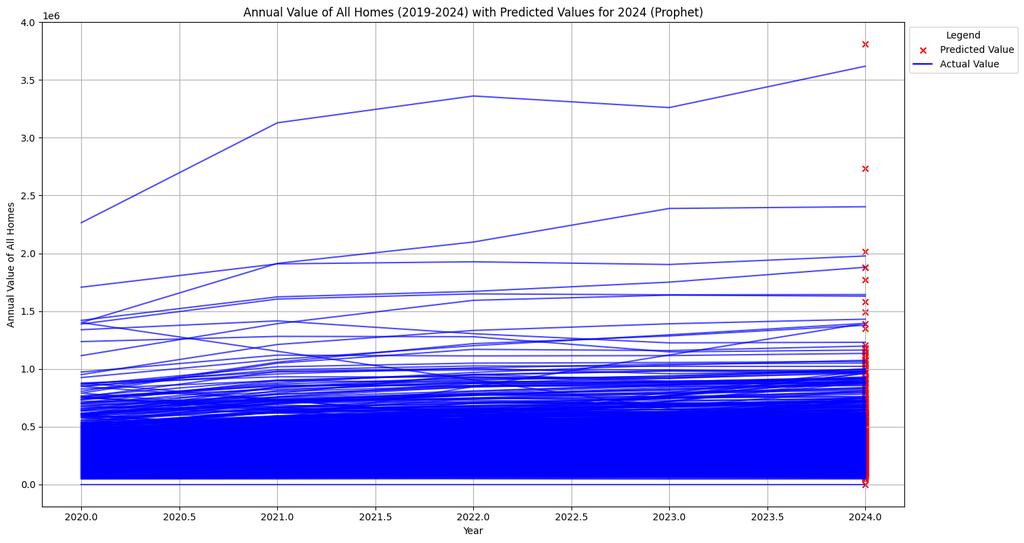

```python
import matplotlib.pyplot as plt

# Ensure 'Type' column is set to 'Predicted' for Prophet predictions
prophet_predict_results_allhomes_df['Type'] = 'Predicted'

# Rename columns to match the actual data for concatenation
prophet_predict_results_allhomes_df.rename(columns={'Predicted': 'AnnualValue_AllHomes', 'Year': 'Year_Recorded'}, inplace=True)

# Filter the predicted data to include only the year 2024
prophet_predict_results_allhomes_df = prophet_predict_results_allhomes_df[prophet_predict_results_allhomes_df['Year_Recorded'] == 2024]

# Concatenate the actual and predicted data
plot_prophet_df = pd.concat([merged_df, prophet_predict_results_allhomes_df[['County', 'State', 'Year_Recorded', 'AnnualValue_AllHomes', 'Type']]])

# Plot the data
plt.figure(figsize=(15, 8))

# Plot actual values
actual_data = plot_prophet_df[plot_prophet_df['Type'] == 'Actual']
for county in actual_data['County'].unique():
    county_data = actual_data[actual_data['County'] == county]
    plt.plot(county_data['Year_Recorded'], county_data['AnnualValue_AllHomes'], color='blue', alpha=0.7)

# Highlight predicted values with a different marker
predicted_data = plot_prophet_df[plot_prophet_df['Type'] == 'Predicted']
plt.scatter(predicted_data['Year_Recorded'], predicted_data['AnnualValue_AllHomes'], color='red', label='Predicted Value', marker='x')

# Add labels and legend
plt.title('Annual Value of All Homes (2019-2024) with Predicted Values for 2024 (Prophet)')
plt.xlabel('Year')
plt.ylabel('Annual Value of All Homes')
plt.plot([], [], color='blue', label='Actual Value')  # Add a dummy plot for the legend
plt.legend(loc='upper left', bbox_to_anchor=(1, 1), title='Legend')
plt.grid(True)
plt.tight_layout()
plt.show()
```

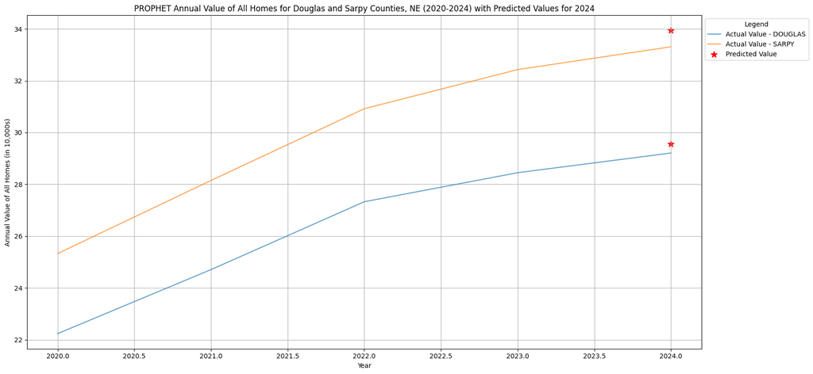

```python
import matplotlib.pyplot as plt
from matplotlib.ticker import FuncFormatter, MultipleLocator

# Merge actual values from zhvi_condo_fmt_df and predicted values from arima_predict_results_df
merged_df = zhvi_condo_fmt_df[['County', 'State', 'Year_Recorded', 'AnnualValue_AllHomes']].copy()
merged_df['Type'] = 'Actual'

# Add predicted values to the merged dataframe
prophet_predict_results_allhomes_df['Type'] = 'Predicted'
prophet_predict_results_allhomes_df.rename(columns={'Predicted_2024': 'AnnualValue_AllHomes'}, inplace=True)
prophet_predict_results_allhomes_df['Year_Recorded'] = 2024  # Ensure the year is set to 2024

# Concatenate the actual and predicted data
plot_df = pd.concat([merged_df, prophet_predict_results_allhomes_df[['County', 'State', 'Year_Recorded', 'AnnualValue_AllHomes', 'Type']]])

# Filter for specific County and State (Douglas, NE)
plot_df = plot_df[(plot_df['County'].isin(['DOUGLAS', 'SARPY'])) & (plot_df['State'] == 'NE')]

# Remove duplicates if they exist
plot_df = plot_df.drop_duplicates(subset=['County', 'State', 'Year_Recorded', 'Type'])

# Sort data based on State, County, and Year_Recorded
plot_df = plot_df.sort_values(by=['State', 'County', 'Year_Recorded', 'Type'])

# Plot the data
plt.figure(figsize=(15, 8))

# Plot actual values for 'DOUGLAS' and 'SARPY' counties in 'NE'
actual_data = plot_df[plot_df['Type'] == 'Actual']
for county in actual_data['County'].unique():
    county_data = actual_data[actual_data['County'] == county]
    plt.plot(county_data['Year_Recorded'], county_data['AnnualValue_AllHomes'], label=f'Actual Value - {county}', alpha=0.7)

# Highlight predicted values with a different marker
predicted_data = plot_df[plot_df['Type'] == 'Predicted']
if not predicted_data.empty:
    plt.scatter(predicted_data['Year_Recorded'], predicted_data['AnnualValue_AllHomes'], color='red', label='Predicted Value', marker='*', s=100)

# Add labels and legend
plt.title('PROPHET Annual Value of All Homes for Douglas and Sarpy Counties, NE (2020-2024) with Predicted Values for 2024')
plt.xlabel('Year')
plt.ylabel('Annual Value of All Homes (in 10,000s)')

# Add custom y-axis formatter
formatter_y = FuncFormatter(lambda x, _: f'{int(x / 10000)}')  # Custom format to show units of 10,000 for y-axis
plt.gca().yaxis.set_major_formatter(formatter_y)


# Set grid and adjust the layout
plt.grid(True)

# Add annotation on y-axis to explain the formatting (22 means 22 * 10,000)
##plt.text(2020, 22, '22 means 22 * 10,000', fontsize=12, color='black', ha='center', va='center',
 ##        rotation=90, bbox=dict(facecolor='white', edgecolor='black', boxstyle='round,pad=0.5'))

# Add annotations to explain y-axis formatting
##plt.text(2020, 220, 'Values are in units of 10,000\n(i.e., 22 means 22 * 10,000)',
##         fontsize=12, color='black', ha='center', va='center', bbox=dict(facecolor='white', edgecolor='black', boxstyle='round,pad=0.5'))

# Adjust layout for better display
plt.tight_layout()

# Add the legend
plt.legend(loc='upper left', bbox_to_anchor=(1, 1), title='Legend')

# Show the plot
plt.show()
```

Build LSTM Time Series Forecasting Univariate Model . This Model is to forecast one value at a time . This Model is called as PyTorch-based LSTM model for univariate time series forecasting

```python
import torch
import torch.nn as nn
from torch.utils.data import DataLoader, Dataset

# Function to train and evaluate the model for a given target column
import numpy as np
import pandas as pd
from sklearn.preprocessing import MinMaxScaler
from sklearn.model_selection import train_test_split
from sklearn.metrics import mean_squared_error

# Define the LSTM model
class LSTMModel(nn.Module):
    def __init__(self, input_size, hidden_size, num_layers, output_size):
        super(LSTMModel, self).__init__()
        self.lstm = nn.LSTM(input_size, hidden_size, num_layers, batch_first=True)
        self.fc = nn.Linear(hidden_size, output_size)

    def forward(self, x):
        h0 = torch.zeros(num_layers, x.size(0), hidden_size).to(x.device)
        c0 = torch.zeros(num_layers, x.size(0), hidden_size).to(x.device)
        out, _ = self.lstm(x, (h0, c0))
        out = self.fc(out[:, -1, :])  # Take the last output
        return out

# Custom dataset for time series
class TimeSeriesDataset(Dataset):
    def __init__(self, data, seq_length):
        self.data = data
        self.seq_length = seq_length

    def __len__(self):
        return len(self.data) - self.seq_length

    def __getitem__(self, index):
        x = self.data[index:index + self.seq_length]
        y = self.data[index + self.seq_length]
        return torch.tensor(x, dtype=torch.float32), torch.tensor(y, dtype=torch.float32)

# Prepare the data
def prepare_data(data, target_column, seq_length):
    scaler = MinMaxScaler()
    data_scaled = scaler.fit_transform(data[[target_column]])
    dataset = TimeSeriesDataset(data_scaled, seq_length)
    train_size = int(len(dataset) * 0.8)
    test_size = len(dataset) - train_size
    train_dataset, test_dataset = torch.utils.data.random_split(dataset, [train_size, test_size])
    return train_dataset, test_dataset, scaler

# Training function
def train_model(model, train_loader, criterion, optimizer, num_epochs):
    model.train()
    for epoch in range(num_epochs):
        for x_batch, y_batch in train_loader:
            device = torch.device('cuda' if torch.cuda.is_available() else 'cpu')

            x_batch, y_batch = x_batch.to(device), y_batch.to(device)
            optimizer.zero_grad()
            outputs = model(x_batch)
            loss = criterion(outputs, y_batch)
            loss.backward()
            optimizer.step()
        #print(f'Epoch [{epoch+1}/{num_epochs}], Loss: {loss.item():.4f}')

# Prediction function
def predict(model, test_loader, scaler):
    model.eval()
    predictions, actuals = [], []
    device = torch.device('cuda' if torch.cuda.is_available() else 'cpu')  # Define device
    with torch.no_grad():
        for x_batch, y_batch in test_loader:
            x_batch = x_batch.to(device)
            outputs = model(x_batch)
            predictions.extend(outputs.cpu().numpy())
            actuals.extend(y_batch.numpy())
    predictions = scaler.inverse_transform(predictions)
    actuals = scaler.inverse_transform(np.array(actuals).reshape(-1, 1))
    return predictions, actuals

# Hyperparameters
input_size = 1
hidden_size = 50
num_layers = 2
output_size = 1
seq_length = 12
num_epochs = 50
learning_rate = 0.001
batch_size = 32

def train_and_evaluate(target_column):
    # Prepare the dataset
    train_dataset, test_dataset, scaler = prepare_data(zhvi_condo_fmt_df, target_column, seq_length)
    train_loader = DataLoader(train_dataset, batch_size=batch_size, shuffle=True)
    test_loader = DataLoader(test_dataset, batch_size=batch_size, shuffle=False)

    # Initialize the model, loss function, and optimizer
    device = torch.device('cuda' if torch.cuda.is_available() else 'cpu')
    model = LSTMModel(input_size, hidden_size, num_layers, output_size).to(device)
    criterion = nn.MSELoss()
    optimizer = torch.optim.Adam(model.parameters(), lr=learning_rate)

    # Train the model
    train_model(model, train_loader, criterion, optimizer, num_epochs)

    # Make predictions
    predictions, actuals = predict(model, test_loader, scaler)

    # Calculate RMSE
    rmse = np.sqrt(mean_squared_error(actuals, predictions))

    # Convert predictions and actuals to a DataFrame for comparison
    results_df = pd.DataFrame({'Actual': actuals.flatten(), 'Predicted': predictions.flatten()})

    return rmse, results_df

# Target columns to evaluate
target_columns = ['AnnualValue_AllHomes', 'AnnualValue_TwoBedRoom', 'AnnualValue_ThreeBedRoom','AnnualValue_Condo', 'AnnualValue_SingleFamily']

# Store RMSE and results for each target column
results_lstm_allhomes = {}
results_lstm_twobedroom = {}
results_lstm_threebedroom = {}
results_lstm_condo = {}
results_lstm_singlefamily = {}

for target in target_columns:
    rmse, results_df = train_and_evaluate(target)
    if target == 'AnnualValue_AllHomes':
        results_lstm_allhomes['RMSE'] = rmse
        results_lstm_allhomes['Results'] = results_df
    elif target == 'AnnualValue_TwoBedRoom':
        results_lstm_twobedroom['RMSE'] = rmse
        results_lstm_twobedroom['Results'] = results_df
    elif target == 'AnnualValue_ThreeBedRoom':
        results_lstm_threebedroom['RMSE'] = rmse
        results_lstm_threebedroom['Results'] = results_df
    elif target == 'AnnualValue_Condo':
        results_lstm_condo['RMSE'] = rmse
        results_lstm_condo['Results'] = results_df
    elif target == 'AnnualValue_SingleFamily':
        results_lstm_singlefamily['RMSE'] = rmse
        results_lstm_singlefamily['Results'] = results_df
```

```python
# Fixing the code to correctly calculate Test MAE for all categories
results_allhomes = pd.DataFrame({
    'Category': ['AllHomes'],
    'Test RMSE': [int(round(results_lstm_allhomes['RMSE']))],
    'Test MAE': [int(round(np.mean(np.abs(results_lstm_allhomes['Results']['Actual'] - results_lstm_allhomes['Results']['Predicted']))))]
})

results_twobedroom = pd.DataFrame({
    'Category': ['TwoBedRoom'],
    'Test RMSE': [int(round(results_lstm_twobedroom['RMSE']))],
    'Test MAE': [int(round(np.mean(np.abs(results_lstm_twobedroom['Results']['Actual'] - results_lstm_twobedroom['Results']['Predicted']))))]
})

results_threebedroom = pd.DataFrame({
    'Category': ['ThreeBedRoom'],
    'Test RMSE': [int(round(results_lstm_threebedroom['RMSE']))],
    'Test MAE': [int(round(np.mean(np.abs(results_lstm_threebedroom['Results']['Actual'] - results_lstm_threebedroom['Results']['Predicted']))))]
})

# Adding placeholders for Condo and SingleFamily categories if no results are available
results_condo = pd.DataFrame({
    'Category': ['Condo'],
    'Test RMSE': [int(round(results_lstm_condo['RMSE']))],
    'Test MAE': [int(round(np.mean(np.abs(results_lstm_condo['Results']['Actual'] - results_lstm_condo['Results']['Predicted']))))]
})

results_singlefamily = pd.DataFrame({
    'Category': ['SingleFamily'],
    'Test RMSE': [int(round(results_lstm_singlefamily['RMSE']))],
    'Test MAE': [int(round(np.mean(np.abs(results_lstm_singlefamily['Results']['Actual'] - results_lstm_singlefamily['Results']['Predicted']))))]
})

# Combine all results into one dataframe
lstm_results_df = pd.concat([results_allhomes, results_twobedroom, results_threebedroom, results_condo, results_singlefamily], ignore_index=True)
lstm_results_df
```

|  | Category | Test RMSE | Test MAE |
| --- | --- | --- | --- |
| 0 | AllHomes | 71016 | 34060 |
| 1 | TwoBedRoom | 53779 | 27982 |
| 2 | ThreeBedRoom | 77104 | 43983 |
| 3 | Condo | 58377 | 28932 |
| 4 | SingleFamily | 76808 | 39787 |

```python
lstm_results_df
```

|  | Category | Test RMSE | Test MAE |
| --- | --- | --- | --- |
| 0 | AllHomes | 71016 | 34060 |
| 1 | TwoBedRoom | 53779 | 27982 |
| 2 | ThreeBedRoom | 77104 | 43983 |
| 3 | Condo | 58377 | 28932 |
| 4 | SingleFamily | 76808 | 39787 |

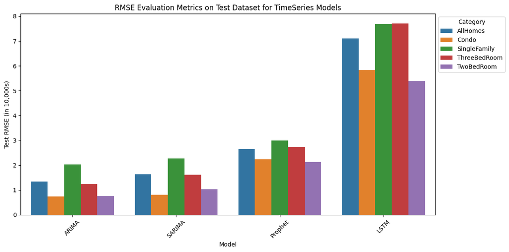

```python
import seaborn as sns
import matplotlib.pyplot as plt

# Merge the results into one dataframe
merged_results = pd.concat([arima_results_df, sarima_results_df, prophet_results_df, lstm_results_df],
                           keys=['ARIMA', 'SARIMA', 'Prophet', 'LSTM'],
                           names=['Model', 'Index']).reset_index()

# Set the order of categories with 'AllHomes' first
category_order = ['AllHomes', 'Condo', 'SingleFamily', 'ThreeBedRoom', 'TwoBedRoom']
merged_results['Category'] = pd.Categorical(merged_results['Category'], categories=category_order, ordered=True)

# Sort the results by Category and Test RMSE
sorted_results = merged_results.sort_values(by=['Category', 'Test RMSE'])

# Define a discrete color palette
palette = sns.color_palette("tab10", n_colors=len(category_order))

# Plot the results
plt.figure(figsize=(12, 6))
ax = sns.barplot(data=sorted_results, x='Model', y='Test RMSE', hue='Category', palette=palette)

# Update Y-axis labels to show values in multiples of 10,000
plt.gca().set_yticklabels([int(label) // 10000 for label in plt.gca().get_yticks()])
plt.title('RMSE Evaluation Metrics on Test Dataset for TimeSeries Models')
plt.xlabel('Model')
plt.ylabel('Test RMSE (in 10,000s)')
plt.xticks(rotation=45)
plt.legend(title='Category', loc='upper left', bbox_to_anchor=(1, 1))
plt.tight_layout()
plt.show()
```

```python
sorted_results
```

|  | Model | Index | Category | Test RMSE | Test MAE |
| --- | --- | --- | --- | --- | --- |
| 1 | ARIMA | 1 | Condo | 7440 | 2770 |
| 4 | ARIMA | 4 | TwoBedRoom | 7550 | 4060 |
| 6 | SARIMA | 1 | Condo | 8014 | 3212 |
| 9 | SARIMA | 4 | TwoBedRoom | 10247 | 6704 |
| 3 | ARIMA | 3 | ThreeBedRoom | 12290 | 5900 |
| 0 | ARIMA | 0 | AllHomes | 13370 | 7060 |
| 8 | SARIMA | 3 | ThreeBedRoom | 16149 | 11019 |
| 5 | SARIMA | 0 | AllHomes | 16329 | 11350 |
| 2 | ARIMA | 2 | SingleFamily | 20300 | 7340 |
| 14 | Prophet | 4 | TwoBedRoom | 21250 | 11320 |
| 11 | Prophet | 1 | Condo | 22410 | 9090 |
| 7 | SARIMA | 2 | SingleFamily | 22607 | 11673 |
| 10 | Prophet | 0 | AllHomes | 26460 | 15530 |
| 13 | Prophet | 3 | ThreeBedRoom | 27390 | 15630 |
| 12 | Prophet | 2 | SingleFamily | 29920 | 16010 |
| 16 | LSTM | 1 | TwoBedRoom | 53779 | 27982 |
| 18 | LSTM | 3 | Condo | 58377 | 28932 |
| 15 | LSTM | 0 | AllHomes | 71016 | 34060 |
| 19 | LSTM | 4 | SingleFamily | 76808 | 39787 |
| 17 | LSTM | 2 | ThreeBedRoom | 77104 | 43983 |

Based on these Time Series Model Builds; ARIMA has better RMSE under Time Series Models when compared to SARIMA, PROPHET and LSTM Models .